# E-commerce data EDA for Customer Behavior Analysis

EDA (Exploratory Data Analysis) of E-Commerce data will help us understand the data and think of ways to use it to understand the customer behavior.

## 1. Load libraries

```python
import pandas as pd
import matplotlib.pyplot as plt
import seaborn as sns
import numpy as np
import plotly.express as px
from matplotlib.gridspec import GridSpec
from scipy.stats import chi2_contingency
from sklearn.model_selection import train_test_split
from sklearn.tree import DecisionTreeClassifier
from sklearn.ensemble import RandomForestClassifier
from sklearn.metrics import classification_report
```

## 2. Load Data

```python
# read in the data (downloaded from Kaggle)
cb_df = pd.read_csv(r"D:\DAB\3nd - DAB\DAB303-25F-002 MARKETING ANALYTICS - PRATIK BEDI\Labs - W1\Week7_Lab\Project 3 Files\Customer_Behavior_Data.csv", delimiter=';')

# print the first 5 rows
cb_df.head()
```

|  | account length | location code | user id | credit card info save | push status | add to wishlist | desktop sessions | app sessions | desktop transactions | total product detail views | session duration | promotion clicks | avg order value | sale product views | discount rate per visited products | product detail view per app session | app transactions | add to cart per session | customer service calls | churn |
| --- | --- | --- | --- | --- | --- | --- | --- | --- | --- | --- | --- | --- | --- | --- | --- | --- | --- | --- | --- | --- |
| 0 | 128 | 415 | 3824657 | no | yes | 25 | 265 | 45 | 17 | 110 | 197 | 87 | 244,7 | 91 | 11,01 | 10 | 3 | 2,7 | 1 | 0 |
| 1 | 107 | 415 | 3717191 | no | yes | 26 | 162 | 27 | 17 | 123 | 196 | 103 | 254,4 | 103 | 11,45 | 13,7 | 3 | 3,7 | 1 | 0 |
| 2 | 137 | 415 | 3581921 | no | no | 0 | 243 | 41 | 10 | 114 | 121 | 110 | 162,6 | 104 | 7,32 | 12,2 | 5 | 3,29 | 0 | 0 |
| 3 | 84 | 408 | 3759999 | yes | no | 0 | 299 | 51 | 5 | 71 | 62 | 88 | 196,9 | 89 | 8,86 | 6,6 | 7 | 1,78 | 2 | 0 |
| 4 | 75 | 415 | 3306626 | yes | no | 0 | 167 | 28 | 13 | 113 | 148 | 122 | 186,9 | 121 | 8,41 | 10,1 | 3 | 2,73 | 3 | 0 |

```python
cb_df.info()
```

```
<class 'pandas.core.frame.DataFrame'>
RangeIndex: 3333 entries, 0 to 3332
Data columns (total 20 columns):
 #   Column                               Non-Null Count  Dtype
---  ------                               --------------  -----
 0   account length                       3333 non-null   int64
 1   location code                        3333 non-null   int64
 2   user id                              3333 non-null   int64
 3   credit card info save                3333 non-null   object
 4   push status                          3333 non-null   object
 5   add to wishlist                      3333 non-null   int64
 6   desktop sessions                     3333 non-null   int64
 7   app sessions                         3333 non-null   int64
 8   desktop transactions                 3333 non-null   int64
 9   total product detail views           3333 non-null   int64
 10  session duration                     3333 non-null   int64
 11  promotion clicks                     3333 non-null   int64
 12  avg order value                      3333 non-null   object
 13  sale product views                   3333 non-null   int64
 14  discount rate per visited products   3333 non-null   object
 15  product detail view per app session  3333 non-null   object
 16  app transactions                     3333 non-null   int64
 17  add to cart per session              3333 non-null   object
 18  customer service calls               3333 non-null   int64
 19  churn                                3333 non-null   int64
dtypes: int64(14), object(6)
memory usage: 520.9+ KB
```

## EDA

With every new dataset we need to got through an EDA (Exploratory Data Analysis) process. It's a good idea to have a basic framework in mind for our EDAs. It is always a good idea to:

- Understand what our columns say
- Rename columns labels and make them lowercase
- Make sure that the data types of columns are correct
- Handle missing values
- Check for duplicates
- Search for outliers
- Check for linearity between variables

To achieve this we can take advantage of Pandas and visualisation libraries

```python
# Check column names
cb_df.columns
```

```
Index(['account length', 'location code', 'user id', 'credit card info save',
       'push status', 'add to wishlist', 'desktop sessions', 'app sessions',
       'desktop transactions', 'total product detail views',
       'session duration', 'promotion clicks', 'avg order value',
       'sale product views', 'discount rate per visited products',
       'product detail view per app session', 'app transactions',
       'add to cart per session', 'customer service calls', 'churn'],
      dtype='object')
```

```python
# Rename columns to make them more 'pythonic' by replacing spaces with underscores
cb_df.columns = cb_df.columns.str.replace(' ', '_')

cb_df.columns
```

```
Index(['account_length', 'location_code', 'user_id', 'credit_card_info_save',
       'push_status', 'add_to_wishlist', 'desktop_sessions', 'app_sessions',
       'desktop_transactions', 'total_product_detail_views',
       'session_duration', 'promotion_clicks', 'avg_order_value',
       'sale_product_views', 'discount_rate_per_visited_products',
       'product_detail_view_per_app_session', 'app_transactions',
       'add_to_cart_per_session', 'customer_service_calls', 'churn'],
      dtype='object')
```

```python
# check the column types and some basic information of the data with the .info() function
cb_df.info()
```

```
<class 'pandas.core.frame.DataFrame'>
RangeIndex: 3333 entries, 0 to 3332
Data columns (total 20 columns):
 #   Column                               Non-Null Count  Dtype
---  ------                               --------------  -----
 0   account_length                       3333 non-null   int64
 1   location_code                        3333 non-null   int64
 2   user_id                              3333 non-null   int64
 3   credit_card_info_save                3333 non-null   object
 4   push_status                          3333 non-null   object
 5   add_to_wishlist                      3333 non-null   int64
 6   desktop_sessions                     3333 non-null   int64
 7   app_sessions                         3333 non-null   int64
 8   desktop_transactions                 3333 non-null   int64
 9   total_product_detail_views           3333 non-null   int64
 10  session_duration                     3333 non-null   int64
 11  promotion_clicks                     3333 non-null   int64
 12  avg_order_value                      3333 non-null   object
 13  sale_product_views                   3333 non-null   int64
 14  discount_rate_per_visited_products   3333 non-null   object
 15  product_detail_view_per_app_session  3333 non-null   object
 16  app_transactions                     3333 non-null   int64
 17  add_to_cart_per_session              3333 non-null   object
 18  customer_service_calls               3333 non-null   int64
 19  churn                                3333 non-null   int64
dtypes: int64(14), object(6)
memory usage: 520.9+ KB
```

```python
# change the data-type of the 4 columns to float
cb_df['avg_order_value'] = cb_df['avg_order_value'].replace(',','.', regex=True).astype(float)
cb_df['discount_rate_per_visited_products'] = cb_df['discount_rate_per_visited_products'].replace(',','.', regex=True).astype(float)
cb_df['add_to_cart_per_session'] = cb_df['add_to_cart_per_session'].replace(',','.', regex=True).astype(float)
cb_df['product_detail_view_per_app_session'] = cb_df['product_detail_view_per_app_session'].replace(',','.', regex=True).astype(float)

cb_df.dtypes
```

```
account_length                           int64
location_code                            int64
user_id                                  int64
credit_card_info_save                   object
push_status                             object
add_to_wishlist                          int64
desktop_sessions                         int64
app_sessions                             int64
desktop_transactions                     int64
total_product_detail_views               int64
session_duration                         int64
promotion_clicks                         int64
avg_order_value                        float64
sale_product_views                       int64
discount_rate_per_visited_products     float64
product_detail_view_per_app_session    float64
app_transactions                         int64
add_to_cart_per_session                float64
customer_service_calls                   int64
churn                                    int64
dtype: object
```

## Statistical Analysis

Are there missing values in the data? (see .info() results) so we can move on and check our descriptive statistics with the .describe() function.

```python
# descriptive statistics for numeric columns after the conversion
cb_df.describe()
```

|  | account_length | location_code | user_id | add_to_wishlist | desktop_sessions | app_sessions | desktop_transactions | total_product_detail_views | session_duration | promotion_clicks | avg_order_value | sale_product_views | discount_rate_per_visited_products | product_detail_view_per_app_session | app_transactions | add_to_cart_per_session | customer_service_calls | churn |
| --- | --- | --- | --- | --- | --- | --- | --- | --- | --- | --- | --- | --- | --- | --- | --- | --- | --- | --- |
| count | 3333.000000 | 3333.000000 | 3.333000e+03 | 3333.000000 | 3333.000000 | 3333.000000 | 3333.000000 | 3333.000000 | 3333.000000 | 3333.000000 | 3333.000000 | 3333.000000 | 3333.000000 | 3333.000000 | 3333.000000 | 3333.000000 | 3333.000000 | 3333.000000 |
| mean | 101.064806 | 437.182418 | 3.746291e+06 | 8.099010 | 179.811881 | 30.567957 | 17.087609 | 100.435644 | 201.039604 | 100.110711 | 200.872037 | 100.107711 | 9.039325 | 10.237294 | 4.479448 | 2.764581 | 1.562856 | 0.144914 |
| std | 39.822106 | 42.371290 | 2.746626e+05 | 13.688365 | 54.457135 | 9.269376 | 4.323795 | 20.069084 | 50.714359 | 19.923911 | 50.573847 | 19.568609 | 2.275873 | 2.791840 | 2.461214 | 0.753773 | 1.315491 | 0.352067 |
| min | 1.000000 | 408.000000 | 3.271058e+06 | 0.000000 | 0.000000 | 0.000000 | 0.000000 | 0.000000 | 0.000000 | 0.000000 | 23.200000 | 33.000000 | 1.040000 | 0.000000 | 0.000000 | 0.000000 | 0.000000 | 0.000000 |
| 25% | 74.000000 | 408.000000 | 3.508680e+06 | 0.000000 | 144.000000 | 24.000000 | 14.000000 | 87.000000 | 167.000000 | 87.000000 | 167.000000 | 87.000000 | 7.520000 | 8.500000 | 3.000000 | 2.300000 | 1.000000 | 0.000000 |
| 50% | 101.000000 | 415.000000 | 3.748187e+06 | 0.000000 | 179.000000 | 31.000000 | 17.000000 | 101.000000 | 201.000000 | 100.000000 | 201.200000 | 100.000000 | 9.050000 | 10.300000 | 4.000000 | 2.780000 | 1.000000 | 0.000000 |
| 75% | 127.000000 | 510.000000 | 3.985970e+06 | 20.000000 | 216.000000 | 37.000000 | 20.000000 | 114.000000 | 235.000000 | 114.000000 | 235.300000 | 113.000000 | 10.590000 | 12.100000 | 6.000000 | 3.270000 | 2.000000 | 0.000000 |
| max | 243.000000 | 510.000000 | 4.229964e+06 | 51.000000 | 351.000000 | 60.000000 | 31.000000 | 165.000000 | 364.000000 | 170.000000 | 395.000000 | 175.000000 | 17.770000 | 20.000000 | 20.000000 | 5.400000 | 9.000000 | 1.000000 |

```python
# descriptive statistics for non-numeric columns (after the conversion)
cb_df.describe(exclude= np.number)
```

|  | credit_card_info_save | push_status |
| --- | --- | --- |
| count | 3333 | 3333 |
| unique | 2 | 2 |
| top | no | no |
| freq | 3010 | 2411 |

## 3. Handle Missing Values

Missing values can be an issue with most real-life datasets. We can use the .info() function, there are no missing values. For the sake of double checking and to show a way of checking whether the dataset has missing values, let's write some code below

```python
# Check missing values and sort data by descending order
cb_df.isnull().sum().sort_values(ascending=False)
```

```
account_length                         0
location_code                          0
user_id                                0
credit_card_info_save                  0
push_status                            0
add_to_wishlist                        0
desktop_sessions                       0
app_sessions                           0
desktop_transactions                   0
total_product_detail_views             0
session_duration                       0
promotion_clicks                       0
avg_order_value                        0
sale_product_views                     0
discount_rate_per_visited_products     0
product_detail_view_per_app_session    0
app_transactions                       0
add_to_cart_per_session                0
customer_service_calls                 0
churn                                  0
dtype: int64
```

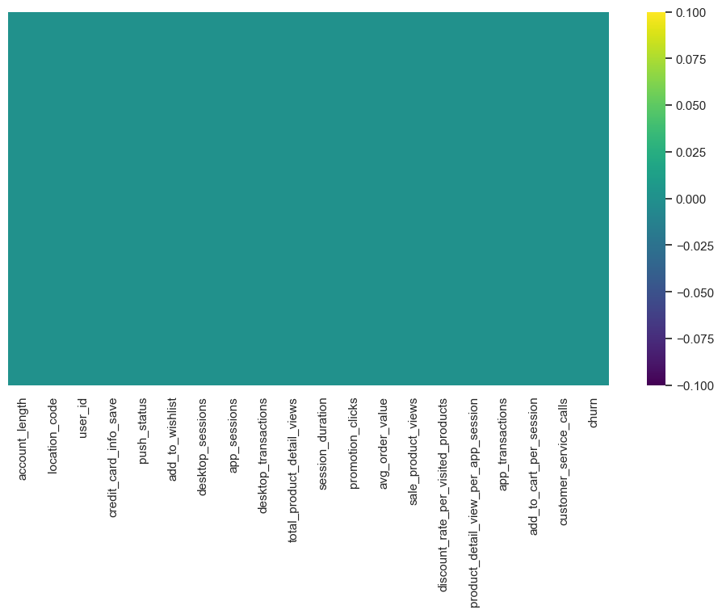

```python
# A pretty way to check for missing values is to visualize it
plt.figure(figsize=(12,6))
sns.heatmap(cb_df.isnull(), yticklabels=False, cbar=True, cmap='viridis')
```

## 4. Check for duplicates

Another common issue with data is duplicated records. We need to make sure to always check for duplicates

```python
# Let's start by checking whether all user ids are unique
## If we find duplicated user ids we'll have to understand if there is a reason for appearing more than once in the data
cb_df.user_id.nunique()
```

```
3333
```

## 5. Search for outliers

- Outliers are data points at the extreme points of a dataset.
- Some outliers represent true values from natural variation in the population and some occur because of dirty or incorect data.
  - Because of this, we need to be careful when we cleanse our data
  - If the outliers are True outliers, we should probably keep them in our data since they represent natural variations in our sample
  - If the outliers are errors we should generally remove those data points

We've already identified some potential outliers from our .describe() function with session durations, average order value, promotion clicks, sale product views, app transactions, account length, add to wish list, desktop sessions, and customer service calls.

To identify our outliers we can use:

- Visualisations such as histograms and blox plots
- Use interquartiles with rules such as:
  - outlier < Q1 - 1.5(IQR)
  - outlier > Q3 + 1.5(IQR)

```python
# Columns need to check outliers
columns_to_check = ['session_duration', 'avg_order_value', 'promotion_clicks',
                    'sale_product_views', 'app_transactions', 'account_length',
                    'add_to_wishlist', 'desktop_sessions', 'customer_service_calls']

# Print summary statistics for all columns to inspect visually
print(cb_df[columns_to_check].describe())
```

```
       session_duration  avg_order_value  promotion_clicks  \
count       3333.000000      3333.000000       3333.000000
mean         201.039604       200.872037        100.110711
std           50.714359        50.573847         19.923911
min            0.000000        23.200000          0.000000
25%          167.000000       167.000000         87.000000
50%          201.000000       201.200000        100.000000
75%          235.000000       235.300000        114.000000
max          364.000000       395.000000        170.000000

       sale_product_views  app_transactions  account_length  add_to_wishlist  \
count         3333.000000       3333.000000     3333.000000      3333.000000
mean           100.107711          4.479448      101.064806         8.099010
std             19.568609          2.461214       39.822106        13.688365
min             33.000000          0.000000        1.000000         0.000000
25%             87.000000          3.000000       74.000000         0.000000
50%            100.000000          4.000000      101.000000         0.000000
75%            113.000000          6.000000      127.000000        20.000000
max            175.000000         20.000000      243.000000        51.000000

       desktop_sessions  customer_service_calls
count       3333.000000             3333.000000
mean         179.811881                1.562856
std           54.457135                1.315491
min            0.000000                0.000000
25%          144.000000                1.000000
50%          179.000000                1.000000
75%          216.000000                2.000000
max          351.000000                9.000000
```

```python
# Define a function to detect outliers
def detect_outliers(column):
    Q1 = column.quantile(0.25)
    Q3 = column.quantile(0.75)
    IQR = Q3 - Q1

    lower_bound = Q1 - 1.5 * IQR
    upper_bound = Q3 + 1.5 * IQR

    outliers = column[(column < lower_bound) | (column > upper_bound)]
    return outliers, len(outliers) > 0  # Return outliers and whether any were found

# Check for outliers in the specified columns
outliers_summary = {}
for col in columns_to_check:
    outliers, has_outliers = detect_outliers(cb_df[col])
    outliers_summary[col] = (outliers, has_outliers)

# Print which columns have outliers
print("Columns with Outliers:")
for col, (outliers, has_outliers) in outliers_summary.items():
    if has_outliers:
        print(f"{col}: {len(outliers)} outliers found")
    else:
        print(f"{col}: No outliers found")
```

```
Columns with Outliers:
session_duration: 25 outliers found
avg_order_value: 30 outliers found
promotion_clicks: 20 outliers found
sale_product_views: 22 outliers found
app_transactions: 78 outliers found
account_length: 18 outliers found
add_to_wishlist: 1 outliers found
desktop_sessions: 27 outliers found
customer_service_calls: 267 outliers found
```

```python
# Optionally remove outliers
for col in columns_to_check:
    outliers = detect_outliers(cb_df[col])
    cb_df = cb_df[~cb_df[col].isin(outliers)]
```

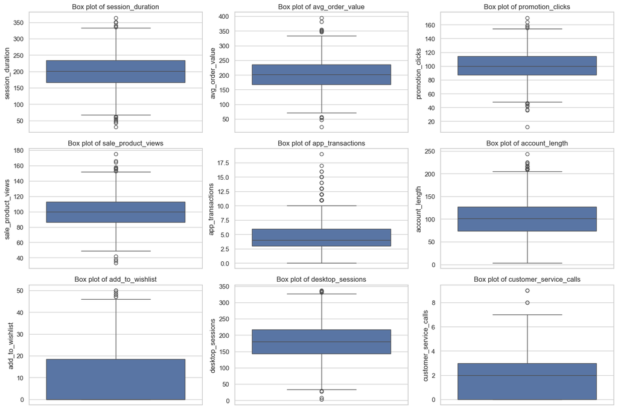

```python
# Set the aesthetic style of the plots
sns.set(style="whitegrid")

# Create box plots for each column to visualize outliers
plt.figure(figsize=(15, 10))
for i, col in enumerate(columns_to_check):
    plt.subplot(3, 3, i + 1)
    sns.boxplot(y=cb_df[col])
    plt.title(f'Box plot of {col}')
plt.tight_layout()
plt.show()
```

5.1 Account length

```python
# Histogram of account length
acl_fig = px.histogram(cb_df, x="account_length")
acl_fig.show()

## Data is distributed normally, with some extreme outliers above 230 (depending on your point of view, maybe everything above 200)
```

[output not shown]

```python
# Box plot of account length
acl_bx_fig = px.box(cb_df, y='account_length')

acl_bx_fig.show()

## The box plot makes it a bit clearer, here we can argue that everything above 208 length is an outlier
```

[output not shown]